# Empirical Risk Minimization

David Childers

## Statistical Learning: Review

- Usual Setup
  - Data $\mathcal{Y}_{T+h}=\{y_{t}\}_{t=1}^{T+h}$
  - Goal is to produce forecast $\widehat{y}_{T+h}$ of $y_{T+h}$ using forecasting rule $\widehat{y}_{T+h}=f(\mathcal{Y}_{T})$
- Statistical machine learning approach builds on **probability** model
  - Series $\mathcal{Y}_{T+h}$ comes from a **true** but **unknown** probability distribution $p\in\mathcal{P}$
  - Want to obtain small **risk** $R_{p}(f)=E_{p}\ell(y_{T+h},\widehat{y}_{T+h})$ for any true $p\in\mathcal{P}$
- Goal is to do well relative to one of two possible comparisons
  - **Oracle risk** of class $\mathcal{F}$ of forecasting rules: $R^{*}_{p}(\mathcal{F})=\underset{f\in\mathcal{F}}{\inf}R_{p}(f)$
  - **Empirical Risk** $\widehat{R}(f)=\frac{1}{T-h}\sum_{t=1}^{T-h}\ell(y_{t+h},f(\mathcal{Y}_{t}))$
- A forecasting rule $\widehat{f}$ should have small values, for any $p\in\mathcal{P}$ of
  - **Excess risk** $R_p(\widehat{f})-R^{*}_{p}(\mathcal{F})$
  - **Generalization Error** $R_p(\widehat{f})-\widehat{R}(\widehat{f})$

## Empirical Risk Minimization

- Given loss function $\ell(.,.)$ and class of forecasting rules $\mathcal{F}$, a useful method is the **Empirical Risk Minimizer**
  $$\widehat{f}^{ERM}(\mathcal{Y}_{T})=\underset{f\in\mathcal{F}}{\min}\widehat{R}(f)$$
- Uses rule in the class with best past performance
  - This is dangerous! In general, this need not give good results.
- When is this good idea?
  - Only if $\mathcal{P}$ and $\mathcal{F}$ satisfy very particular conditions
- Previous class: both excess risk and generalization error of $\widehat{f}^{ERM}$ are bounded above by (constant times)
  - **Uniform Error** $\underset{f\in\mathcal{F}}{\sup}\left|\widehat{R}(f)-R_p(f)\right|$
- Look for conditions on $\mathcal{P}$ and $\mathcal{F}$ so that $\forall p\in\mathcal{P}$ Uniform Error is small

## When is uniform error small?

- Uniform bound can be guaranteed to be true under certain conditions on $\mathcal{P}$ and $\mathcal{F}$
  - Here, “small” means bounded above by something that goes to 0 as amount of data increases
  - May not actually be small without long history of observations
- Note that this only a good idea if true $p$ is actually in $\mathcal{P}$
  - Risk criteria controls average loss over distribution $p$
  - If realizations not like those from $p$, realized performance may be bad
- Conditions on $\mathcal{P}$
  - **Stationarity**: The future is “like” the past
  - **Ergodicity** or **Weak Dependence**: Averages are close to expectations
- Conditions on $\mathcal{F}$
  - **Uniformity** or limited **Complexity**: Closeness is true for any $f$ we pick

## Distribution conditions

- **Stationarity** means that shifting backwards or forwards in time doesn’t change distribution
  - $\forall\mathcal{T}\subset\mathbb{N}$, $\forall{h}$, for any event $A$, $p(\{y_t\}_{t\in\mathcal{T}}\in A)=p(\{y_{t+h}\}_{t\in\mathcal{T}}\in A)$
  - Rules out deterministic seasonality, trends, breaks or shifts
  - If you see these, good chance that it fails!
- **Ergodicity** means sample average is usually close to mean in large samples
  - $p(\left|\frac{1}{T}\sum_{t=1}^{T}g(y_t)-E_p g(y_t)\right|>c)\to 0\text{ as }T\to\infty$
- **Weak dependence** strengthens error bound on mean to hold for finite T
  - Rules out series where cyclical fluctuations last “too long” relative to length T of sample
  - Requires values far apart in time to be close to independent

## Nonstationary Series: Simulations

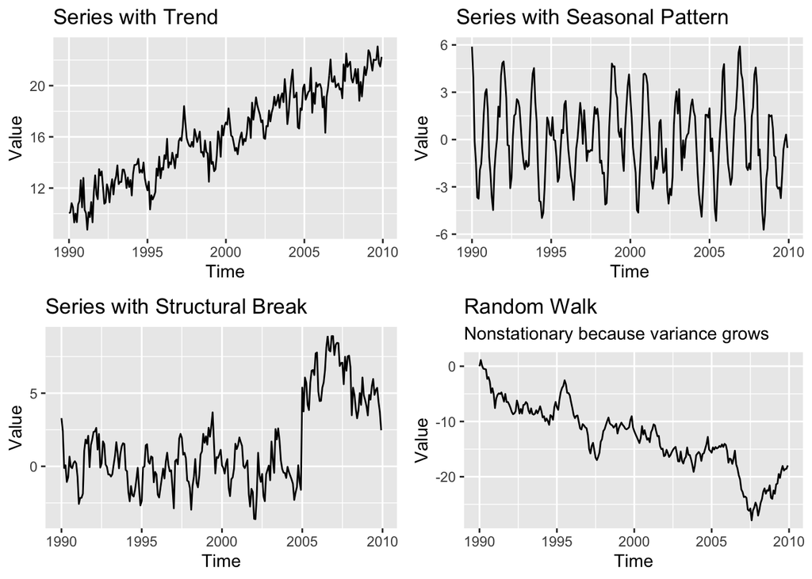

```r
library(knitr) #Tables
library(fpp2) #Forecast commands
library(kableExtra) #More tables
library(tidyverse) #Data manipulation
library(gridExtra) #Graph Display


tl<-240 #Length of simulated series
set.seed(55) #Initialize random number generator for reproducibility
e1<-ts(rnorm(tl)) #standard normal shocks
e2<-ts(rnorm(tl)) #standard normal shocks
e3<-ts(rnorm(tl)) #standard normal shocks
e4<-ts(rnorm(tl)) #standard normal shocks
rho<-0.7 #AR1 parameter
#AR2 parameters
b0<-3
b1<-0.4
b2<-0.3
ss<-0.98 #LArge AR parameter
yAR1<-numeric(tl)
yAR1[1]<-(1/(1-rho))*rnorm(1) #Initialize at random draw
yRW<-numeric(tl)
yslowAR<-numeric(tl)

for(s in 1:(tl-1)){
  #Stationary AR(1)
  yAR1[s+1]<-rho*yAR1[s]+e1[s]
  #Stationary but close to nonstationary AR(1)
  yslowAR[s+1]<-ss*yslowAR[s]+e4[s]
  #Random walk
  yRW[s+1]<-yRW[s]+e3[s]
}

yAR2<-numeric(tl)
yAR2[1]<-3/0.3 #Initialize at mean
yAR2[2]<-3/0.3 #Initialize at mean

for(s in 1:(tl-2)){
  #Stationary AR(2)
  yAR2[s+2]=b0+b1*yAR2[s+1]+b2*yAR2[s]+e2[s]
}

trend<-0.05*seq(1,tl) #Increasing trend
season<-cos((2*pi/12)*seq(1,tl)) #Seasonal pattern
#Jump at particular time
breakseries<-ts(numeric(tl),start=c(1990,1),frequency=12)
for(s in 1:(tl)){
  if(s>180){
    breakseries[s]<-6
  }
}


#Represent as time series
yAR1<-ts(yAR1, start=c(1990,1),frequency=12)
yRW<-ts(yRW, start=c(1990,1),frequency=12)
yAR2<-ts(yAR2,start=c(1990,1),frequency=12)
yslowAR<-ts(yslowAR,start=c(1990,1),frequency=12)

#Construct nonstationary series
ytrend<-yAR2+trend
yseason<-yAR1+3*season
ybreak<-yAR1+breakseries

tsgraphs<-list()

tsgraphs[[1]]<-autoplot(ytrend)+
  labs(y="Value",title="Series with Trend")
tsgraphs[[2]]<-autoplot(yseason)+
  labs(y="Value",title="Series with Seasonal Pattern")
tsgraphs[[3]]<-autoplot(ybreak)+
  labs(y="Value",title="Series with Structural Break")
tsgraphs[[4]]<-autoplot(yRW)+
  labs(y="Value",title="Random Walk",subtitle="Nonstationary because variance grows")

grid.arrange(grobs=tsgraphs,nrow=2,ncol=2) #Arrange In 2x2 grid
```

## Stationary Series: Simulations

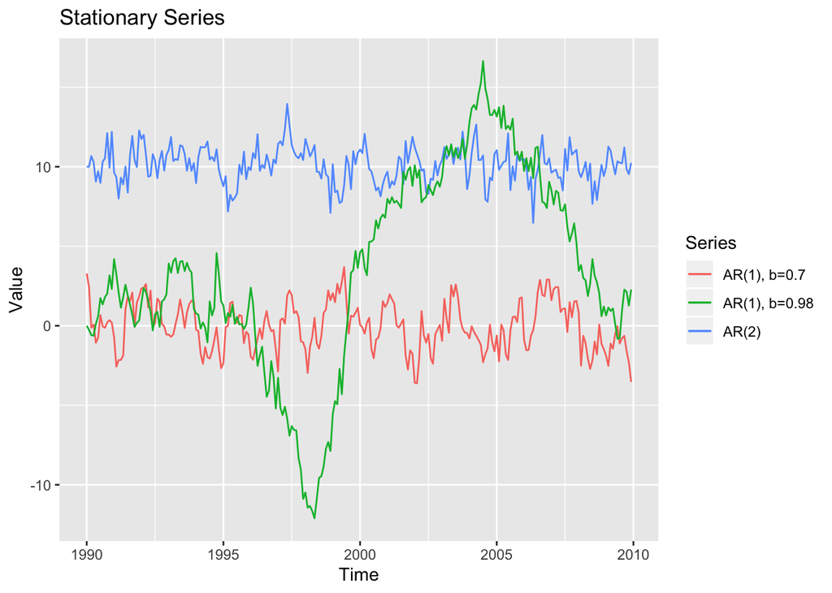

```r
autoplot(yAR1,series="AR(1), b=0.7")+autolayer(yAR2,series="AR(2)")+autolayer(yslowAR,series="AR(1), b=0.98")+
  labs(y="Value",title="Stationary Series")+
  guides(colour=guide_legend(title="Series"))
```

## Evaluating Stationarity and Weak Dependence

- How far sample mean is from population mean controlled by dependence
- Variance: $E_p[y_t^2]-E_p[y_t]^2$ measures how far a variable deviates from mean
- Variance of sample mean $Var(\frac{1}{T}\sum_{t=1}^{T}z_t)=\frac{1}{T^2}\sum_{s=1}^{T}\sum_{t=1}^{T}Cov(z_t,z_{s})$
  - With stationarity, equals sum of autocovariances $Cov(z_1,z_1)+2\sum_{h=1}^{T-1}\frac{T-h}{T}Cov(z_1,z_{1+h})\overset{T\to\infty}{\to}\sum_{h=-\infty}^{+\infty}Cov(z_1,z_{1+h})$
  - If small, sample mean and population mean usually close
  - If large or unbounded, sample mean may be arbitrarily far away
- Rules of thumb: autocovariances approximated by ACF, so
  - If ACF falls to 0 exponentially fast, approximation is close
  - If ACF goes to 0 but (polynomially) slowly, approximation works but need much more data
  - If ACF decay looks like straight line, stationarity likely fails: approximation bad no matter how much data you have
- Consider distributions $\mathcal{P}$ where for any bounded $f,g$, $Corr(f(y_{t}),g(y_{t+h}))<\rho(h)$ for some function $\rho(h)\to0$
  - These are called $\rho$-mixing: Autocorrelation Function goes to 0
  - Can replace correlation with other measures to get other types of mixing
  - Ensures sufficient closeness for uniform bounds to work

## ACFs of Example Series

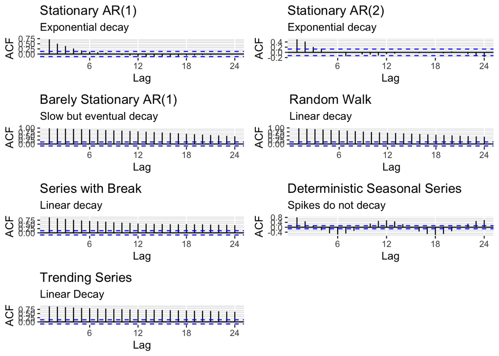

```r
ACFplots<-list()
ACFplots[[1]]<-ggAcf(yAR1)+
  labs(title="Stationary AR(1)",subtitle="Exponential decay")
ACFplots[[2]]<-ggAcf(yAR2)+
  labs(title="Stationary AR(2)",subtitle="Exponential decay")
ACFplots[[3]]<-ggAcf(yslowAR)+
  labs(title="Barely Stationary AR(1)",subtitle="Slow but eventual decay")
ACFplots[[4]]<-ggAcf(yRW)+
  labs(title="Random Walk",subtitle="Linear decay")
ACFplots[[5]]<-ggAcf(ybreak)+
  labs(title="Series with Break",subtitle="Linear decay")
ACFplots[[6]]<-ggAcf(yseason)+
  labs(title="Deterministic Seasonal Series",subtitle="Spikes do not decay")
ACFplots[[7]]<-ggAcf(ytrend)+
  labs(title="Trending Series",subtitle="Linear Decay")
grid.arrange(grobs=ACFplots,nrow=4,ncol=2)
```

## ACF of US Dollar Exchange Rates in 1970s

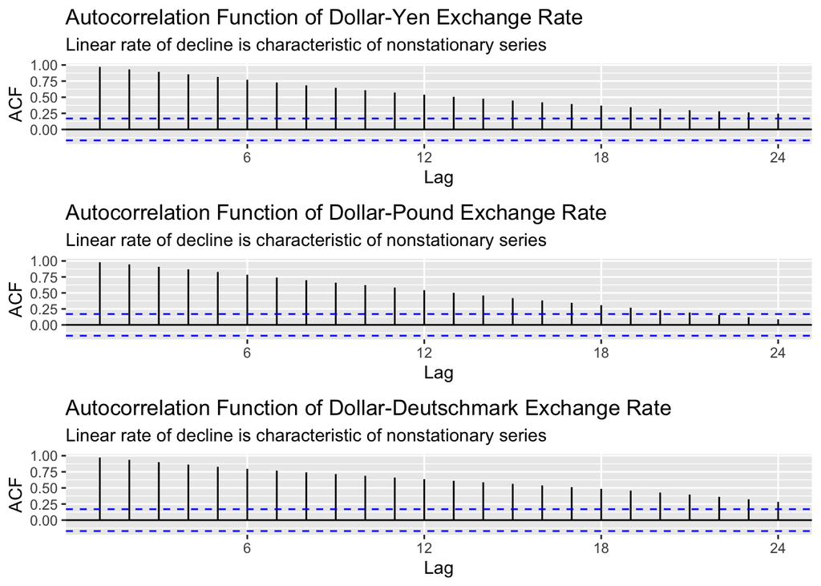

```r
library(fpp2)
library(fredr) #Access FRED, the Federal Reserve Economic Data
#To access data by API, using R rather than going to the website and downloading
#You need to request a key: you can do so at https://research.stlouisfed.org/docs/api/api_key.html
fredr_set_key("8782f247febb41f291821950cf9118b6") #Key I obtained for this class
#Get 1970s data
#Let's get the (main) series for the Yen-Dollar Exchange rate
EXJPUS<-fredr(series_id = "EXJPUS",observation_end=as.Date("1982-01-04"))
#You can also download this series at https://fred.stlouisfed.org/series/DEXJPUS
#Let's get the (main) series for the Dollar-Pound Exchange rate
EXUSUK<-fredr(series_id = "EXUSUK",observation_end=as.Date("1982-01-04"))
#Let's get the (main) series for the German Deutschmark-Dollar Exchange rate
EXGEUS<-fredr(series_id = "EXGEUS",observation_end=as.Date("1982-01-04"))
#convert to time series and normalize so 1971-1 value is 1
ukus<-ts(EXUSUK$value[1]/EXUSUK$value,start=c(1971,1),frequency=12)
jpus<-ts(EXJPUS$value/EXJPUS$value[1],start=c(1971,1),frequency=12)
geus<-ts(EXGEUS$value/EXGEUS$value[1],start=c(1971,1),frequency=12)

currACFplots<-list()
currACFplots[[1]]<-ggAcf(jpus)+
  labs(title="Autocorrelation Function of Dollar-Yen Exchange Rate",subtitle = "Linear rate of decline is characteristic of nonstationary series")
currACFplots[[2]]<-ggAcf(ukus)+
  labs(title="Autocorrelation Function of Dollar-Pound Exchange Rate",subtitle = "Linear rate of decline is characteristic of nonstationary series")
currACFplots[[3]]<-ggAcf(geus)+
  labs(title="Autocorrelation Function of Dollar-Deutschmark Exchange Rate",subtitle = "Linear rate of decline is characteristic of nonstationary series")
grid.arrange(grobs=currACFplots)
```

## Conditions on Hypothesis Class

- For uniform error control need $\mathcal{F}$ to be “not too complicated”
- Many measures of complexity used
- $\left|\mathcal{F}\right|$ Number of hypotheses
  - Compare method 1, method 2, method 3, etc
  - If $\log\left|\mathcal{F}\right|\approx T$, uniformity fails
  - Note, hypothesis should not itself be based on choosing from many hypotheses
- Dimension of parameter space
  - Eg, AR(p) class $\mathcal{F}=\{f(\mathcal{Y}_T)=b_0+b_1y_{t-1}+b_2y_{T-2}+\ldots b_py_{T-p}:\ b\in\mathbb{R}^{p+1}\}$ has dimension $p+1$
  - If dimension of parameter space $\approx T$, uniformity fails
- Maximum correlation of predictor with random noise
  - $\underset{f\in\mathcal{F}}{\max}E_{\sigma}\frac{1}{T}\sum_{t=1}^T\sigma_tf(\mathcal{Y}_t)$, $\sigma_t\overset{iid}{\sim}\{-1,+1\}$ w/ prob (1/2,1/2)
  - Called **Rademacher Complexity**
  - If some $f\in{F}$ can perfectly match iid random noise, expect low error even with **no** true forecasting ability
- Choosing from too complicated a set of forecast rules means in sample fit can be good but out of sample fit terrible

## Controlling Uniform Error: Theory

- Many beautiful mathematical results exist giving upper bounds on uniform error for different classes $\mathcal{P}$, $\mathcal{F}$
- Form of these bounds (eg Yu (1994), Mohri et al (2008, 2012)) is: for any $p\in\mathcal{P}$ with probability at least $1-\delta$,
  $$\underset{f\in\mathcal{F}}{\sup}\left|\frac{1}{T}\sum_{t=1}^{T}f(y_{t})-E_p f(y_t)\right|\leq b(\delta,T,complexity(\mathcal{F}), dependence(\mathcal{P}))$$
- For any distribution over sequences with some properties, uniform error over a class $\mathcal{F}$ of sample average can be bounded with high probability by some function
- Bound goes to 0 as $T\to\infty$, so for large enough sample, probability of large uniform error disappears
- Bound increasing in some measure of size or *complexity* of $\mathcal{F}$
  - For finite set, this is number of possible choices
  - For models with continuous parameters (eg $\theta_0,\theta_1$) other measures, like number of parameters or Rademacher complexity, can be used
- Bound increasing in measure of how strong dependence is between samples
  - If iid or nearly so, error decreases with T
  - If observations highly correlated, so events 5 years apart are related, need much longer time to get same approximation

## Controlling Generalization Error: Practical Advice

- I did not provide precise statement or proof of generalization error bound theorems
  - Usually statement is very complicated, and provable bounds very loose
- Takeaway: overfitting of ERM is small when
  - Distribution is stationary and correlations over time go to 0 quickly
  - Model size not too large: small number of choices, or few parameters
  - Sample size is large: for small model classes and fast enough decay, generalization error bounded by constant times $\frac{1}{\sqrt{T}}$
- ERM does fine in these situations
  - Excess risk $R_p(\widehat{f}^{ERM})-R_p(f^{*})$ and generalization error $R_p(\widehat{f})-\widehat{R}(\widehat{f})$ are small
- Can do poorly if models class is very complicated, data is strongly dependent or nonstationary, or samples are small
- In those cases, good in sample performance may still give bad out of sample performance in future predictions

## What happens if these conditions fail?

- Generalization error bounds are upper bounds
  - Sometimes error is smaller than predicted
- But if no guarantee or large upper bound, generalization error can be very bad
  - With nonstationarity, it may not become smaller as time grows
  - Without weak dependence, permitted error may be huge until T huge
- ERM minimizes one component of risk, but total risk might not be minimized
  - There are some cases where better options than ERM exist
  - With complicated models, total risk may be worse for ERM than some other method

## Simulations Showing Overfitting as Function of Complexity

- Consider AR(d) classes $\mathcal{F}_d=\{f(\mathcal{Y}_T)=b_0+b_1y_{t-1}+b_2y_{T-2}+\ldots b_dy_{T-d}:\ b\in\mathbb{R}^{d+1}\}$
- Use square loss $\ell(y,\widehat{y})=(y-\widehat{y})^2$
  - Empirical risk is Mean Squared Error (MSE)
  - Optimal forecast is the conditional mean
- Simulate series $\mathcal{Y}_T$ of length $T$ from a distribution $p$
  - For simplicity of exposition and analysis, let $p$ be IID N(0,1)
  - Stationary and as weakly dependent as possible, so we can focus on complexity only
  - Best possible forecast is $\widehat{y}=0$ and oracle risk is 1
- Run ERM over data for each $\mathcal{F}_p$
- Simulate many times to calculate average empirical risk and average population risk
  - Average population risk $E_p[(y_{T+1}-\widehat{f}^{ERM}(\mathcal{Y}_T))^2]$
  - $=E_{\mathcal{Y}_T}[E_{y_{T+1}}[(y_{T+1}-\widehat{f}^{ERM}(\mathcal{Y}_T))^2|\mathcal{Y}_T]]=E_{\mathcal{Y}_T}[1+(\widehat{f}^{ERM}(\mathcal{Y}_T))^2]\approx 1+\frac{1}{N_{sims}}\sum_{n=1}^{N_{sims}}(\widehat{f}^{ERM}(\mathcal{Y}^{n}_T))^2$ by iid law of large numbers
  - Average empirical risk approximated by $\frac{1}{N_{sims}}\sum_{n=1}^{N_{sims}}MSE(\widehat{f}^{ERM}_n)$
- Compute average generalization error by average difference of empirical and population risk
  - Compute quantile (object bounded by theory) by quantile of difference over simulations

## Simulation Results

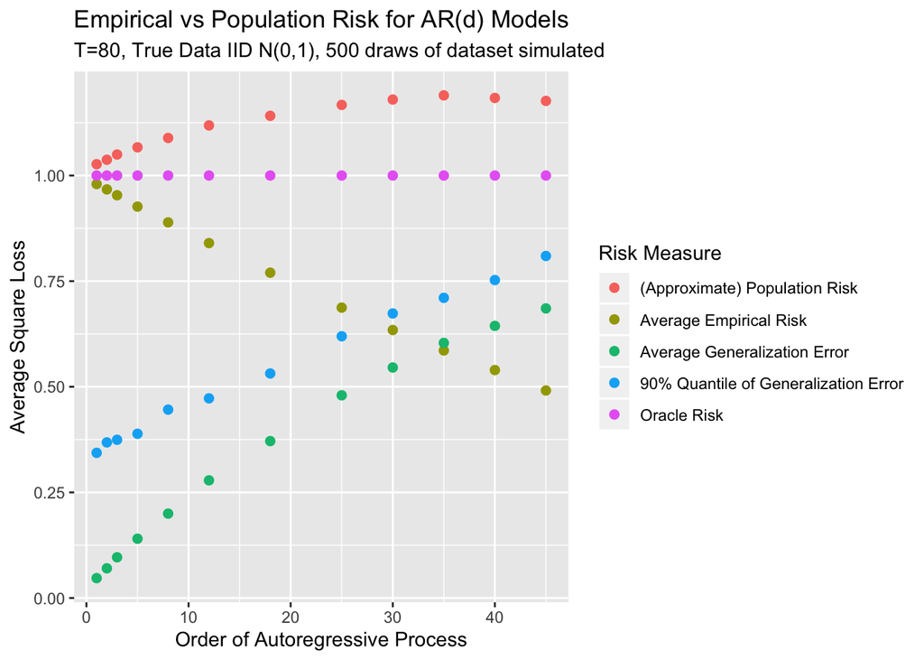

```r
#Tlist<-c(50,100,300,500,1000)
Tlist<-c(80)
plist<-c(1,2,3,5,8,12,18,25,30,35,40,45)
nsims<-500

generalizationerror<-matrix(nrow=length(Tlist),ncol=length(plist))

for(T in 1:length(Tlist)){
  empiricalrisk<-matrix(nrow=nsims,ncol=length(plist))
  fcast<-matrix(nrow=nsims,ncol=length(plist))
  for(n in 1:nsims){
    datasim<-ts(rnorm(Tlist[T]))

    for(p in 1:length(plist)){
      arfc<-ar(datasim,aic = FALSE,order = plist[p])
      fcast[n,p]<-forecast(arfc,1)$mean
      empiricalrisk[n,p]<-mean((arfc$resid)^2,na.rm =TRUE)
    }
  }
  approxrisk<-1+colMeans(fcast^2)
      #Population risk is average over data sets of conditional risk given data
      #Conditional Risk given data is just mean squared error over y of fixed forecast yhat
      #E_p(y-yhat)^2=1+yhat^2 using fact that true y is iid N(0,1)
  averageemprisk<-colMeans(empiricalrisk)
  generalizationerror[T,]<-approxrisk-averageemprisk
}


generrordist<-approxrisk-empiricalrisk
generrorq90<-numeric(length(plist))

for(p in 1:length(plist)){
       generrorq90[p]<-quantile(generrordist[,p],0.9) #90% quantile of generalization error for model p
}

oraclerisk<-numeric(length(plist))+1 #Oracle risk=1 for all models, because true data iid N(0,1), so optimal forecast is 0, with MSE 1

#Collect into dataset format for plotting
generalizationgap<-as.vector(generalizationerror[1,])
errormeasures<-data.frame(plist,approxrisk,averageemprisk,generalizationgap,generrorq90,oraclerisk)
errortable<-errormeasures %>%
  gather(approxrisk,averageemprisk,generalizationgap,generrorq90,oraclerisk,key="RiskMeasure",value="Risk")

#Plot Results
ggplot(errortable,aes(x=plist,y=Risk,color=RiskMeasure))+geom_point(size=2)+
  scale_color_discrete(labels =
        c("(Approximate) Population Risk", "Average Empirical Risk",
        "Average Generalization Error","90% Quantile of Generalization Error", "Oracle Risk")) +
  labs(title="Empirical vs Population Risk for AR(d) Models",
       subtitle="T=80, True Data IID N(0,1), 500 draws of dataset simulated",
       x="Order of Autoregressive Process",
       y="Average Square Loss",
       color="Risk Measure")
```

## Interpretation

- Average empirical risk goes down with complexity measure $d$
  - Complexity gives better past performance because we are looking at best past performance of any rule in $\mathcal{F}$
  - A fixed rule may perform better or worse in future, with no reason to think it will be either
  - But selecting based on past performance means finding models with good past performance, holding fixed future performance
- Generalization error and excess risk relative to oracle rise with $d$
  - More complicated model gives more opportunity for overfitting
- If we care about population risk, must tradeoff empirical and generalization errors
  - First goes down, second goes up with complexity
- For this simulation, optimum is reached at 0 complexity
  - This is because data distribution has minimal risk in 0 parameter class
  - Not general: if more complexity improves fit, empirical risk can go down faster and optimum reached at some intermediate $d$
- In general, nothing forces tradeoff to be optimized at a “true” class $\mathcal{F}$
  - Generalization error depends basically just on size of $\mathcal{F}$
  - Adding lots of terrible rules to $\mathcal{F}$ just makes generalization error worse
  - Adding low risk rules to $\mathcal{F}$ makes generalization error worse, but total error better

## Generalization Error Control: Alternatives

- One more way to learn about generalization error $R_p(\widehat{f})-\widehat{R}(\widehat{f})$
- Instead of an upper bound, produce an estimate
  - $\widehat{R}(\widehat{f})$ is known, so just need to estimate $R_p(\widehat{f})$
- If we have good estimate of generalization error, can be confident that an estimator with low empirical risk + estimated generalization error will perform well
- How to estimate $R_p(\widehat{f})$?
- $\widehat{R}(\widehat{f})$ is an okay estimate if you already know generalization error is negligible
  - But, especially for ERM, is extremely likely to be an underestimate
  - When same data used for estimating risk and choosing model, model depends on error in risk estimate
  - Produces trivial generalization error estimate

## Validation in practice

- Better choice: Use independent sequence $\{y_s\}_{s=1}^{S}$ with same distribution as $\{y_t\}_{t=1}^T$, called a test set
- Estimate risk by empirical test set risk $\frac{1}{S}\sum_{s=1}^{S}\ell(y_{s+h},\widehat{f}(\mathcal{Y}_s))$
- Since $\widehat{f}$ independent of test set, if distribution stationary and ergodic, can bound approximation error by LLN
  - Don’t need uniform bounds since only have one function
- Problem: Unless data known to be iid, can’t obtain such a test set
  - Or if distribution known, as in simulations above
- Alternative 1: Blocking
  - Split sample into 3 time ordered subsets: Training set, middle, and Test set
  - Run ERM on training set, estimate risk on test set, discard the middle
  - If data stationary and weakly dependent and middle set large, test set close to independent of training
  - Requires discarding data, making sample sizes small
- Alternative 2: forecasting from a rolling origin (time series Cross Validation)
  - Perform ERM on first $t$ and estimate loss from point $t+h$ each time
  - Doesn’t use test data for optimization at any given time point
  - Many ERM iterations required, and not independent since overlapping, so analysis difficult

## Meese and Rogoff, Revisited

- Meese and Rogoff looked at large collection of hypothesis classes for forecasting 1970s exchange rate data
  - Mostly multivariate models with form and variables inspired by 1970s economic theory
  - Variety of parameter selection procedures, but mostly Empirical Risk Minimization
- Training set is 1971-1978, test set is 1978-81 (no middle block)
- Loss functions are MAE, RMSE
- Conclusions
  - Big complicated models produced by economists do very badly
  - Best performer is naive (random walk) forecast: $\widehat{y}_{t+h}=y_t$
  - Random walk forecast performs even better than AR forecast, even though random walk is special case of AR forecast

## What does this tell us?

- What do ERM principles say about good classes of forecasting methods?
- Model should be simple, to reduce overfitting error
  - Economic models have more parameters, whose values may fit to noise and reduce accuracy
  - Fact that AR model (with parameter to choose) does worse than special case of AR model can only be due to overfitting
- For ERM to produce good estimate, data should be stationary and weak dependent
  - Does this apply to exchange rates? We can look at their autocorrelation functions
  - Linear or slower decay occurs when series is trending or otherwise nonstationary
  - See this in all series, suggesting caution about this assumption
- Approximation error should decrease in length $T$ of the sample time series
  - 8 years of data is moderate amount for monthly series
  - But amount error decreases with time depends on strength of dependence
  - If strong, like ACF shows, need much longer series to reduce error same amount

## Interpretation of Results

- Many economists interpreted study as saying that random walk is best economic model of exchange rates
  - Models based on other variables do not help forecast movements
- High persistence of series is what you would expect to see from a random walk
  - More on this in a later class
- But other models also have many features that make ERM forecast display large error
  - This is true regardless of whether models are “true” in sense of providing better probability model of the data
  - Forecasting and estimation are separate tasks
- If goal is to forecast, simplicity is a virtue!

## Next class

- More hypothesis classes
- Finagling stationarity and weak dependence out of clearly nonstationary or highly dependent data

## References

- Richard Meese and Kenneth Rogoff. “Empirical Exchange Rate Models of the Seventies. Do they Fit out of Sample?” Journal of International Economics 14 (1983) pp. 3-24
- Mehryar Mohri, Afshin Rostamizadeh, and Ameet Talwalkar. “Foundations of Machine Learning” MIT Press 2012
  - Textbook treatment of statistical learning
- Mehryar Mohri and Afshin Rostamizadeh “Rademacher Complexity Bounds for Non-I.I.D. Processes” Advances in Neural Information Processing Systems (NIPS 2008). pp 1097-1104, Vancouver, Canada, 2009. MIT Press.
  - Extension of textbook statistical learning results to time series data
- Bin Yu. “Rates of Convergence for Empirical Processes of Stationary Mixing Sequences” The Annals of Probability, Vol. 22, No. 1 (Jan., 1994), pp. 94-116
  - Foundational paper on when ERM works for time series data